# IHA-assignment

Justin Pomeranz

# Overview

This assignment will use the IHA method to explore and quantify how river regulation alters the natural flow regime. You will use real data from the Colorado River at Lee’s Ferry before and after Glen Canyon dam was built.

# Introduction

Rivers are subjected to variation in flow conditions across time. Within a given year, they can be characterized by a natural flow regime (Poff et al. 1990), with predictable and consistent periods of high and low flow conditions.

Dams are built on rivers around the world for numerous reasons including water storage for municipal and agricultural uses, flood control, and hydropower operations, all of which can alter the natural flow regime.

## Glen Canyon Dam

Glen Canyon Dam was built on the Colorado River to generate hydropower and supply municipal and agricultural water to the desert southwest region of the United States. Completed in 1965, the 710-foot tall dam forms Lake Powell, which can store > 25 million acre-feet of water and is one of the largest human-made reservoirs in the US. The reservoir was filled to capacity in 1980, but the level has fluctuated dramatically since then, particularly in recent decades in response to a ~20 year drought.

## Alterations to flow

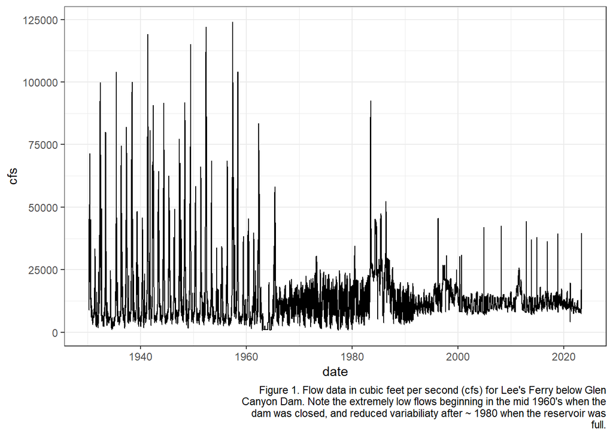

The closing of Glen Canyon Dam dramatically altered the flow at Lee’s Ferry, as seen in figure 1. Qualitatively, we can see much higher variation in the magnitudes of high- and low-flows before the dam closed. Immediately afterwards, the flows decline while the reservoir was filled. After it filled (~80’s), the flows became much more stable and consistent, with higher base flows and lower peak flows.

However, we can go beyond qualitative statements and use the IHA to qunatify the changes to the flow regime.

# Assignment

This assignment will be completed in groups of 2-3 and has four main parts:  
1. Calculate IHA metrics (groups 1 - 3, Richter et al. 1996) For Lee’s ferry before and after the dam was closed.

- This is a total of 48 values
- 12 monthly means, + 10 min/max values across different time windows, + 2 Julian dates = 24 metrics, * 2 timeframes (before/after dam) = 48 values.
2. Use the Range of Variability Approach (RVA, Richter et al. 1997) for selected metrics from group 2 to make management recommendations for Glen Canyon Dam operations.
- RVA for only the 1-, 3-, and 7-day windows in Group 2.
3. Compare your recommendations with flow conditions from experimental high flows in 2023, and experimental low-flows in 2020.
4. You will write up your analysis to summarize and discuss points 1-3.

## Quantifying the IHA and RVA

In this assignment, you will calculate IHA groups 1-3 for both pre- (1930-1939) and post-dam closure data (1990-1999).

The data are available on D2L (`pre_data.csv` and `post_data.csv`, respectively). Tutorials are available on D2L explaining how to calculate the IHA metrics (**IHA tutorial**) for the pre-data as well as the RVA approach (**RVA tutorial**; points 1 and 2 above). A third tutorial (**Plotting the RVA**) Is also available for point 3 above. We will go over these tutorials in class.

**You will be responsible for making the post-data calculations on your own.**

## Comparing with experimental flows

In the last few years, there have been experimental high- and low-flow releases from Glen Canyon Dam to investigate whether or not these flows had ecological benefits. You can read more about the [experimental flood in 2023](https://www.nps.gov/grca/learn/nature/hfe-23.htm), as well as the [experimental low, Bug-flows in 2020](https://www.usbr.gov/newsroom/newsroomold/newsrelease/detail.cfm?RecordID=70708). Daily mean flow data for both of these experiments are available on D2L as `high-flow-2023.csv` and `bug_flows.csv`.

You will need to plot the observed flow data from the experimental flows and compare it to the RVA’s you calculated. You will also need to discuss how the observed flows compare with the RVA. i.e., was the experimental high flow in the RVA for the 1-day maximums, or was it below or above that range?

## Assignment submission

### R scripts

You will need to submit all R scripts used to calculate the IHA and RVA and to plot the RVA vs. experimental flows.

### Writeup

Your writeup should consist of two main parts

1. Compare the flow regime pre- and post-dam. Use the Deviation Magnitude and per cent deviation methods to quantify these changes. What parts of the flow regime have changed? In what way? i.e., high flows higher magnitude, longer duration, shifting time throughout the year? What parts of the flow regime are the same? i.e., are low or base flows the same magnitude and timing, but a different duration?
2. Compare the historical RVA with the experimental flows. Are the experimental flows within the correct range of historical variation? Why or why not? If they are not in the right RVA, what benefits (if any) do you think these experimental flows perform? What reccomendations would you make for future experimental high and low flows?

## Data sources

The data provided for this assignment was downloaded from the USGS website, gauge number 09380000. The downloaded data were curated, cleaned and modified.

If you would like to access the raw, daily data, you can go to the [USGS water data center](https://waterdata.usgs.gov/nwis/dv/?site_no=09380000&referred_module=sw) to download tab-separated data files. You can also view provisional data at the [USGS monitoring site](https://waterdata.usgs.gov/monitoring-location/09380000/#parameterCode=00060&startDT=1920-04-01&endDT=2023-05-01).

If you would like help on how to access, download, and modify the data to be read in to R, please get in touch with me or come to my office hours.